# # Lab05 - Tipos de Redes Neuronales

En la sesion pasada creamos nuestra primera **Red Neuronal Profunda** usando capas densas (*Fully Connected*) ya que se trataba de una regresion lineal sencilla.

Ahora, vamos a crear una **Red Neuronal Convolucional** en un problema muy comun de Inteligencia Artificial: Clasificacion de imagenes!

Trate de instalar estas librerias y de cargarlas en su ambiente de trabajo. Si se encuentra algun error siempre puede trabajar en el ambiente virtual de Docker.

```r
library(tidyr)
library(ggplot2)
library(keras)
library(imager)
```

## Cargar el set de datos

Dependiendo del problema que queramos solucionar, va a ser necesario recolectar una gran cantidad de imagenes para entrenar el modelo. Existen fuentes de datos abiertas para casos de uso generales como: personas, animales, flores, automoviles, etc.  
Por otro lado, cuando nuestro problema es mucho mas particular y no se encuentran datasets ya creados para nuestro caso, sera necesario recolectar las imagenes manualmente. La regla siempre sera: *Entre mas imagenes, mejor*.  
En cualquiera de los dos casos, la estructura recomendable para organizar las imagenes es la siguiente:

```
Directorio Raiz
|--- /train
|   |---- /clase1
|   |    ---- /imagen01.jpg
|   |    ---- /imagen02.jpg
|   |    ---- /...
|   |---- /clase2
|   |    ---- /imagen01.jpg
|   |    ---- /imagen02.jpg
|   |    ---- /...
|   |---- /...
|
|--- /test
|   |---- /clase1
|   |    ---- /imagen01.jpg
|   |    ---- /imagen02.jpg
|   |    ---- /...
|   |---- /clase2
|   |    ---- /imagen01.jpg
|   |    ---- /imagen02.jpg
|   |    ---- /...
|   |---- /...
```

Los directorios no *necesariamante* deben llamarse asi, pero si es recomendable tener un set de datos de entrenamiento separado del de pruebas. Ademas, los **nombres** de las carpetas dentro de estos (clase1, clase2, …), son los que indicaran las **clases/labels** de las imagenes que estan adentro.

Vamos a trabajar con un dataset de Logos de algunas empresas conocidas, se puede descargar de [aqui](http://flovv.github.io/Logo_detection_deep_learning/), pero para facilidad ya se encuentra descargado y organizado en la estructura necesaria dentro de nuestra carpeta */data*:

[figure not shown]

El dataset consta de 675 imagenes de 27 marcas diferentes (En promedio 25 imagenes de cada clase para entrenamiento y pruebas). En un problema real esto es un dataset pequeno, pero hoy nos servira para aprender otros conceptos de Redes Neuronales.

```r
img_width <- 32
img_height <- 32
train_samples <- 498
validation_samples <- 177
classes <- c('Adidas', 'Apple', 'BMW', 'Citroen', 'Cocacola', 'DHL', 'Fedex',
             'Ferrari', 'Ford', 'Google', 'Heineken', 'HP', 'Intel', 'McDonalds',
             'Mini', 'Nbc', 'Nike', 'Pepsi', 'Porsche', 'Puma', 'RedBull',
             'Sprite', 'Starbucks', 'Texaco', 'Unicef', 'Vodafone', 'Yahoo')

train_directory <- "LogoData/train"
test_directory <- "LogoData/test"
```

```r
# Configuracion de Hiperparametros:
batch_size <- 8
learning_rate <- 0.0001
epochs <- 50
```

### Data Augmentation

Como ya se ha mencionado varias veces, entre mas datos tengamos, mejor. En el caso de Computer Vision: entre mas imagenes, mejor. Cuando no tenemos suficientes datos, la tecnica de Data Augmentation permite, por medio de un algoritmo, generar imagenes artificialmente a partir de las pocas imagenes que tenemos. Esto se logra haciendo cambios pequenos a los datos: Girar un poco la imagen, cambiando su luminocidad, resolucion, moviendola un poco, etc. Para nosotros es un cambio pequeno, pero para el modelo es una imagen completamente diferente!

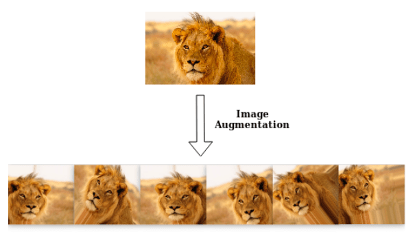

A nivel de codigo, estas son TODAS las opciones que se pueden configurar para el generador de datos, tenga en cuenta que no siempre todas aplican, por ejemplo, la imagen del leon mirando a la derecha o mirando a la izquierda, sigue siendo un leon, pero, nuestros logos?

```r
# Estas son TODAS las opciones!
datagen <- image_data_generator(
  featurewise_center = FALSE,
  samplewise_center = FALSE,
  featurewise_std_normalization = FALSE,
  samplewise_std_normalization = FALSE,
  zca_whitening = FALSE,
  zca_epsilon = 1e-06,
  rotation_range = 0,
  width_shift_range = 0,
  height_shift_range = 0,
  brightness_range = NULL,
  shear_range = 0,
  zoom_range = 0,
  channel_shift_range = 0,
  fill_mode = "nearest",
  cval = 0,
  horizontal_flip = FALSE,
  vertical_flip = FALSE,
  rescale = NULL
)
```

```r
train_generator <- flow_images_from_directory(train_directory, generator = datagen,
                                              target_size = c(img_width, img_height), color_mode = "rgb",
                                              class_mode = "categorical", batch_size = batch_size, shuffle = TRUE,
                                              seed = 123)

validation_generator <- flow_images_from_directory(test_directory, generator = datagen,
                                                   target_size = c(img_width, img_height), color_mode = "rgb", classes = NULL,
                                                   class_mode = "categorical", batch_size = batch_size, shuffle = TRUE,
                                                   seed = 123)
```

Hemos creado dos generadores de imagenes porque cada dataset partira de un directorio diferente, y puede ser con transformaciones diferentes.  
Ahora si, podemos crear el modelo:

```r
model <- keras_model_sequential()

model %>%
  layer_conv_2d(filter = 16, kernel_size = c(3,3), input_shape = c(img_width, img_height, 3)) %>%
  layer_activation("relu") %>%
  layer_max_pooling_2d(pool_size = c(2,2)) %>%

  layer_conv_2d(filter = 32, kernel_size = c(3,3)) %>%
  layer_activation("relu") %>%
  layer_max_pooling_2d(pool_size = c(2,2)) %>%

  layer_flatten() %>%
  layer_dense(64) %>%
  layer_activation("relu") %>%
  layer_dropout(0.5) %>%
  layer_dense(27) %>%    ## we have 27 brand logo classes!
  layer_activation("softmax")

summary(model)
```

```
## Model: "sequential"
## ________________________________________________________________________________
## Layer (type)                        Output Shape                    Param #
## ================================================================================
## conv2d (Conv2D)                     (None, 30, 30, 16)              448
## ________________________________________________________________________________
## activation (Activation)             (None, 30, 30, 16)              0
## ________________________________________________________________________________
## max_pooling2d (MaxPooling2D)        (None, 15, 15, 16)              0
## ________________________________________________________________________________
## conv2d_1 (Conv2D)                   (None, 13, 13, 32)              4640
## ________________________________________________________________________________
## activation_1 (Activation)           (None, 13, 13, 32)              0
## ________________________________________________________________________________
## max_pooling2d_1 (MaxPooling2D)      (None, 6, 6, 32)                0
## ________________________________________________________________________________
## flatten (Flatten)                   (None, 1152)                    0
## ________________________________________________________________________________
## dense (Dense)                       (None, 64)                      73792
## ________________________________________________________________________________
## activation_2 (Activation)           (None, 64)                      0
## ________________________________________________________________________________
## dropout (Dropout)                   (None, 64)                      0
## ________________________________________________________________________________
## dense_1 (Dense)                     (None, 27)                      1755
## ________________________________________________________________________________
## activation_3 (Activation)           (None, 27)                      0
## ================================================================================
## Total params: 80,635
## Trainable params: 80,635
## Non-trainable params: 0
## ________________________________________________________________________________
```

En el resumen que nos entrega el modelo podemos ver:

```r
model %>% compile(
  loss = "categorical_crossentropy",
  optimizer = optimizer_rmsprop(lr = 0.0001, decay = 1e-6),
  metrics = "accuracy"
)
```

```r
hist <- model %>% fit_generator(
  train_generator,
  steps_per_epoch = as.integer(train_samples/batch_size),
  epochs = epochs,
  validation_data = validation_generator,
  validation_steps = as.integer(validation_samples/batch_size),
  verbose=2
)
```

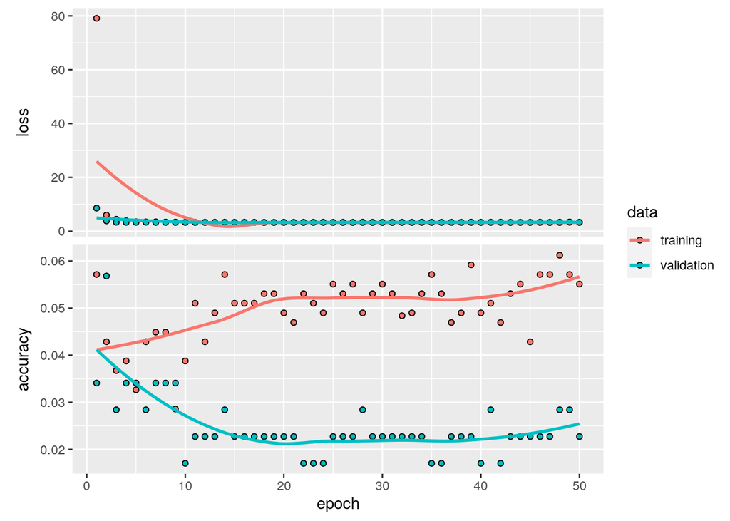

```r
plot(hist)
```

En la grafica de **loss** podemos ver como va disminuyendo nuestro *categorical_crossentropy* en cada epoca.  
Tambien podemos ver los valores finales del loss y el accuracy:

```r
evaluate_generator(model,validation_generator, validation_samples)
```

```
##       loss   accuracy
## 3.31834841 0.02259887
```

Una vez aprobemos nuestro modelo, podemos usarlo para predecir sobre imagenes nuevas:

[figure not shown]

```r
img_path  <- "https://i.pinimg.com/originals/07/0d/3e/070d3e118fa9bcf14bf6a1004308c91b.jpg"
download.file(img_path,'test.jpg', mode = 'wb')
plot(load.image('test.jpg'))
```

```r
img <- image_load('test.jpg', target_size = c(img_width,img_height))
x <- image_to_array(img)
dim(x) <- c(1, dim(x))
prediction <- model %>% predict(x)
prediction
```

```
##            [,1]       [,2]       [,3]       [,4]       [,5]       [,6]
## [1,] 0.03686646 0.03635875 0.03761936 0.03725085 0.03683108 0.03663873
##            [,7]       [,8]       [,9]      [,10]      [,11]      [,12]
## [1,] 0.03813419 0.03714813 0.03701751 0.03621199 0.03730092 0.03707912
##           [,13]      [,14]      [,15]      [,16]      [,17]      [,18]
## [1,] 0.03745393 0.03727354 0.03628648 0.03551457 0.03600936 0.03710152
##           [,19]      [,20]      [,21]      [,22]      [,23]      [,24]
## [1,] 0.03730102 0.03771072 0.03762886 0.03743497 0.03735739 0.03623474
##           [,25]      [,26]      [,27]
## [1,] 0.03667182 0.03800959 0.03755442
```

El resultado de la prediccion es la salida de la ultima neurona, es decir 27 valores que siginifican la probabilidad de que la imagen dada pertenesca a cada una de las 27 clases objetivo.

```r
dim(prediction)
```

```
## [1]  1 27
```

Para saber, entonces, la clase que indica la prediccion basta con elegir la probabilidad mas alta del vector entregado, pues corresponden, por indice a las clases objetivo:

```r
classes[which.max(prediction)]
```

```
## [1] "Fedex"
```

**Taller:**

- Juegue un poco con los hiperparametros, capas y funciones de activacion para mejorar estos valores. Para ello peude usar la documentacion de [keras](https://keras.rstudio.com/reference/index.html)
- Busque otra imagen (*.jpg*) de alguno de los logos en nuestro modelo y haga la prediccion. Funciona? Estamos safisfechos con este modelo? Podria mejorar?

## 5b. Transfer Learning

Para no tener que disenar la red desde ceros, pensando que capas, neuronas y funciones de activacion usar, usamos Transfer Learning, en el que tomamos la estructura de una red ya contruida y especializada en una tarea especifica (Ej: Reconocimiento de imagen).  
Los siguientes pasos iniciales siguen siendo necesarios: - Definicion de hiperprametros - Generador de imagenes nuevas (Data Augemtnation) - Configuracion de generadores para entrenamiento y pruebas

Pero en lugar de crear un modelo desde ceros, vamos a tomar un modelo ya existente, por ejemplo VGG16 y vamos a indicar que sus capas NO SON reentrenables:

```r
base_model <- application_vgg16(weights = 'imagenet', include_top = FALSE)

for (layer in base_model$layers)
  layer$trainable <- FALSE

summary(base_model)
```

```
## Model: "vgg16"
## ________________________________________________________________________________
## Layer (type)                        Output Shape                    Param #
## ================================================================================
## input_1 (InputLayer)                [(None, None, None, 3)]         0
## ________________________________________________________________________________
## block1_conv1 (Conv2D)               (None, None, None, 64)          1792
## ________________________________________________________________________________
## block1_conv2 (Conv2D)               (None, None, None, 64)          36928
## ________________________________________________________________________________
## block1_pool (MaxPooling2D)          (None, None, None, 64)          0
## ________________________________________________________________________________
## block2_conv1 (Conv2D)               (None, None, None, 128)         73856
## ________________________________________________________________________________
## block2_conv2 (Conv2D)               (None, None, None, 128)         147584
## ________________________________________________________________________________
## block2_pool (MaxPooling2D)          (None, None, None, 128)         0
## ________________________________________________________________________________
## block3_conv1 (Conv2D)               (None, None, None, 256)         295168
## ________________________________________________________________________________
## block3_conv2 (Conv2D)               (None, None, None, 256)         590080
## ________________________________________________________________________________
## block3_conv3 (Conv2D)               (None, None, None, 256)         590080
## ________________________________________________________________________________
## block3_pool (MaxPooling2D)          (None, None, None, 256)         0
## ________________________________________________________________________________
## block4_conv1 (Conv2D)               (None, None, None, 512)         1180160
## ________________________________________________________________________________
## block4_conv2 (Conv2D)               (None, None, None, 512)         2359808
## ________________________________________________________________________________
## block4_conv3 (Conv2D)               (None, None, None, 512)         2359808
## ________________________________________________________________________________
## block4_pool (MaxPooling2D)          (None, None, None, 512)         0
## ________________________________________________________________________________
## block5_conv1 (Conv2D)               (None, None, None, 512)         2359808
## ________________________________________________________________________________
## block5_conv2 (Conv2D)               (None, None, None, 512)         2359808
## ________________________________________________________________________________
## block5_conv3 (Conv2D)               (None, None, None, 512)         2359808
## ________________________________________________________________________________
## block5_pool (MaxPooling2D)          (None, None, None, 512)         0
## ================================================================================
## Total params: 14,714,688
## Trainable params: 0
## Non-trainable params: 14,714,688
## ________________________________________________________________________________
```

Vemos la estructura tan compleja que tiene esta red ya preentrenada, mas de 14.5 millones de parametros! En este caso, tambien hemos indicado que este modelo no sea reentrenable.  
Tambien hemos indicado al modelo no incluir la “cabeza” de la red, pues las ultimas capas las vamos a reescribir nosotros mismos:

```r
model_head <- base_model$output %>%
  layer_global_average_pooling_2d(trainable = T) %>%
  layer_dense(64, trainable = T) %>%
  layer_activation("relu", trainable = T) %>%
  layer_dropout(0.4, trainable = T) %>%
  layer_dense(27, trainable=T) %>%    ## important to adapt to fit the 27 classes in the dataset!
  layer_activation("softmax", trainable=T)

my_model <- keras_model(inputs = base_model$input, outputs = model_head)
```

```r
summary(my_model)
```

```
## Model: "model"
## ________________________________________________________________________________
## Layer (type)                        Output Shape                    Param #
## ================================================================================
## input_1 (InputLayer)                [(None, None, None, 3)]         0
## ________________________________________________________________________________
## block1_conv1 (Conv2D)               (None, None, None, 64)          1792
## ________________________________________________________________________________
## block1_conv2 (Conv2D)               (None, None, None, 64)          36928
## ________________________________________________________________________________
## block1_pool (MaxPooling2D)          (None, None, None, 64)          0
## ________________________________________________________________________________
## block2_conv1 (Conv2D)               (None, None, None, 128)         73856
## ________________________________________________________________________________
## block2_conv2 (Conv2D)               (None, None, None, 128)         147584
## ________________________________________________________________________________
## block2_pool (MaxPooling2D)          (None, None, None, 128)         0
## ________________________________________________________________________________
## block3_conv1 (Conv2D)               (None, None, None, 256)         295168
## ________________________________________________________________________________
## block3_conv2 (Conv2D)               (None, None, None, 256)         590080
## ________________________________________________________________________________
## block3_conv3 (Conv2D)               (None, None, None, 256)         590080
## ________________________________________________________________________________
## block3_pool (MaxPooling2D)          (None, None, None, 256)         0
## ________________________________________________________________________________
## block4_conv1 (Conv2D)               (None, None, None, 512)         1180160
## ________________________________________________________________________________
## block4_conv2 (Conv2D)               (None, None, None, 512)         2359808
## ________________________________________________________________________________
## block4_conv3 (Conv2D)               (None, None, None, 512)         2359808
## ________________________________________________________________________________
## block4_pool (MaxPooling2D)          (None, None, None, 512)         0
## ________________________________________________________________________________
## block5_conv1 (Conv2D)               (None, None, None, 512)         2359808
## ________________________________________________________________________________
## block5_conv2 (Conv2D)               (None, None, None, 512)         2359808
## ________________________________________________________________________________
## block5_conv3 (Conv2D)               (None, None, None, 512)         2359808
## ________________________________________________________________________________
## block5_pool (MaxPooling2D)          (None, None, None, 512)         0
## ________________________________________________________________________________
## global_average_pooling2d (GlobalAve (None, 512)                     0
## ________________________________________________________________________________
## dense_2 (Dense)                     (None, 64)                      32832
## ________________________________________________________________________________
## activation_4 (Activation)           (None, 64)                      0
## ________________________________________________________________________________
## dropout_1 (Dropout)                 (None, 64)                      0
## ________________________________________________________________________________
## dense_3 (Dense)                     (None, 27)                      1755
## ________________________________________________________________________________
## activation_5 (Activation)           (None, 27)                      0
## ================================================================================
## Total params: 14,749,275
## Trainable params: 34,587
## Non-trainable params: 14,714,688
## ________________________________________________________________________________
```

Vemos ahora que, la estructura de nuestra nueva red es mucho mas compleja, incluye los 14.5 millones de parametros del modelo VGG16, adicionalmente hemos configurado la capa de entrada para que reciba las imagenes que tenemos preparadas, pero lo mas importante, hemos configurado algunas capas adicionales como la **nueva cabeza** de la red.  
Al final del resumen vemos que, los 14.5 millones de parametros del modelo base (VGG16) no son entrenables, pero los 34mil de nuestra nueva cabeza si, y estos son los valores que va a buscar el modelo.

Hemos creado en pocas lineas un modelo mas complejo, pero mas sencillo de entrenar. Desde aqui la compilacion y entrenamiento del modelo es igual a como ya lo hemos trabajado:

```r
my_model %>% compile(
  loss = "categorical_crossentropy",
  optimizer = optimizer_rmsprop(lr = learning_rate, decay = 1e-6),
  metrics = "accuracy"
)
```

Como paso adicional de este laboratorio vamos a trabajar con los Callbacks que vimos la sesion pasada. Son funciones que se ejecutan al final de cada epoca y que pueden ayudar a mejorar el rendimiento del modelo:

```r
mis_callbacks = list(
  # Modificar el LR si el modelo no mejora:
  callback_reduce_lr_on_plateau(monitor = "val_loss", factor = 0.1, patience=5),
  # Configurar que el modelo pare si no mejora:
  callback_early_stopping(monitor="val_accuracy",patience=10,mode="auto"),
  # Ir guardando el mejor modelo
  callback_model_checkpoint("models/logos_checkpoints.h5", monitor="val_loss", save_best_only = TRUE)
)
```

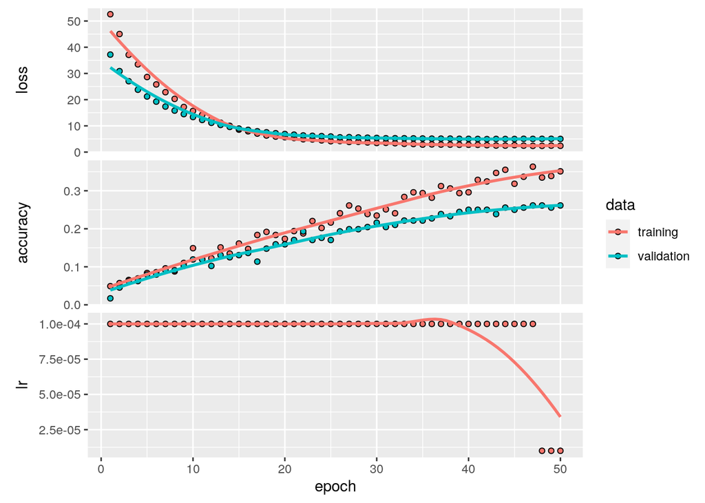

```r
hist <- my_model %>% fit_generator(
  train_generator,
  steps_per_epoch = as.integer(train_samples/batch_size),
  epochs = epochs,
  validation_data = validation_generator,
  validation_steps = as.integer(validation_samples/batch_size),
  verbose=2,
  callbacks = mis_callbacks
)

plot(hist)
```

```r
evaluate_generator(my_model,validation_generator,
                   steps=as.integer(validation_samples/batch_size))
```

```
##      loss  accuracy
## 5.0550151 0.2556818
```

[figure not shown]

```r
img_path  <- "https://i.pinimg.com/originals/02/ac/cd/02accd95989df4cde2f57adcd508dbcd.jpg"
download.file(img_path,'test.jpg', mode = 'wb')
plot(load.image('test.jpg'))
```

```r
img <- image_load('test.jpg', target_size = c(img_width,img_height))
x <- image_to_array(img)
dim(x) <- c(1, dim(x))
prediction <- model %>% predict(x)
prediction
```

[output not shown]

```r
classes[which.max(prediction)]
```

```
## [1] "Fedex"
```

**Taller**

**Ups!** Al modelo le falta un poco de afinamiento, intente:

- Cambiar el modelo base VGG16 por otros modelos como *VGG19, ResNet50, InceptionV3, MobileNet, Xception*. Para ello peude usar la documentacion de [keras](https://keras.rstudio.com/reference/index.html)
- Juegue un poco con los hiperparametros, capas y funciones de activacion en la **cabeza de la red** para mejorar los valores de loss, accuracy y las predicciones.
- Busque otra imagen (*.jpg*) de alguno de los logos en nuestro modelo y haga la prediccion. Funciona? Estamos safisfechos con este modelo? Podria mejorar?